# Eddie module stream discharge from handout

# USGS retreival tool to gather data and analyze flood frequency data

## Install libraries

The libraries need to be installed only one time and then loaded each time the script is opened and run.

```r
# https://github.com/USGS-R/dataRetrieval

# general R packages to install if you dont have them
# remove the "#" if you need to run the installations

# install.packages("devtools") # essential in installing other thigs
# install.packages("tidyverse") # installs a lot of things and ggplot
# install.packages("scales") # allows great scale formatting on ggplot
# install.packages("lubridate") # makes working with dates easier
# install.packages("janitor") # clean names of columns and other things
# install.packages("readxl") # read in excel files
# install.packages("plotly") # interactive plots
# install.packages(skimr)
# devtools::install_github("thomasp85/patchwork") # multiple plots

# specific to this module
# install.packages("dataRetrieval") # USGS Data Retreiveal Method
```

## Load Libraires

Load the libraries each time you run the script.

```r
# load these every time
library(tidyverse)
library(scales)
library(lubridate)
library(janitor)
library(readxl)
library(skimr)
library(plotly)
library(patchwork)

# load the USGS package
library(dataRetrieval)
```

## USGS Sites

These are the sites that are used in the data analysis below. The data can be downloaded again and then used for the analsyses.

USGS 12120000 MERCER CREEK NEAR BELLEVUE, WA https://waterdata.usgs.gov/nwis/inventory/?site_no=12120000

USGS 12113000, Green River near Auburn, Washington https://waterdata.usgs.gov/nwis/inventory/?site_no=12113000

USGS 12108500, Newaukum Creek near Black Diamond, Washington https://waterdata.usgs.gov/nwis/inventory/?site_no=12108500

This reads in the files into a single dataframe that appears in the Environment tab in the upper right.

```r
# Enter the site number below
# Leave the start data and end data open as it will retreive all data
siteNo <-         c("12120000", "12113000", "12108500")
start.date <-     "1800-01-01"
end.date <-       "2050-01-01"

peak_q.df <- readNWISpeak(
              siteNumbers = siteNo,
              startDate = start.date,
              endDate = end.date,
              asDateTime = TRUE,
              convertType = TRUE)

# Clean up the names and remove extra data
peak_q.df <- peak_q.df %>%
  select(agency_cd,
         site_no,
         date = peak_dt,
         discharge_cfs = peak_va,
         gage_ht_ft = gage_ht)
```

## Add site names

This uses case_when which is essentially an if else statment to look at the site number and add a name to the site variable.

```r
peak_q.df <- peak_q.df %>%
  mutate(site = case_when(
    site_no == 12120000 ~ "Mercer Cr",
    site_no == 12113000 ~ "Green R",
    site_no == 12108500 ~ "Newaukum Cr",
    TRUE ~ "other"
  ))
```

## Subdivide the data into 3 separate dtaframes

This will separate the single dataframe into 3 separate dataframes to work with.

```r
green.df <- peak_q.df %>% filter(site == "Green R")

mercer.df <- peak_q.df %>% filter(site == "Mercer Cr")

new.df <- peak_q.df %>% filter(site == "Newaukum Cr")
```

## Graph of yearly peak discharge

This graphs the discharge data from each stream. This is the max flow that occured each year. If the name of a variable is put inside of the aes( here ) statment it will map the values of that vaiable to the type of symbol or color you have designated. These commands may be: `aes(x = x_variable, y = y_variable, *color* = variable name of sites)`  
`aes(x = x_variable, y = y_variable, *fill* = variable name of sites)`  
`aes(x = x_variable, y = y_variable, *shape* = variable name of sites)`  
`aes(x = x_variable, y = y_variable, *line_type* = variable name of sites)`

This is the graph using the commands above and you can try changing these around

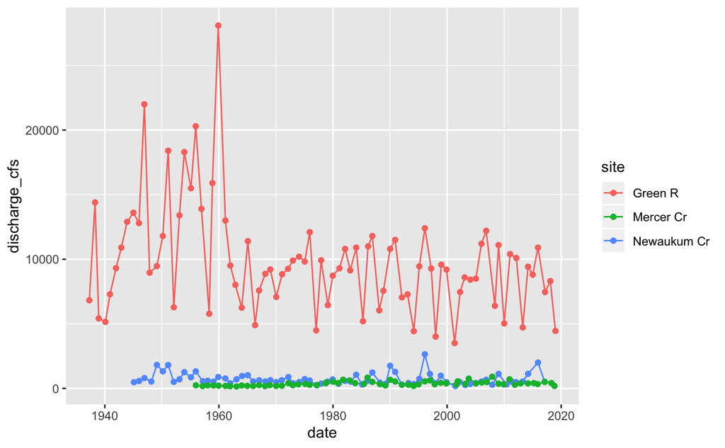

```r
peak_q.df %>%
  ggplot(aes(x = date, y=discharge_cfs, color=site)) +
  geom_line() +
  geom_point()
```

## Table of Highest dischage

There are several ways to obtian the maximum values.  
1) Filter the data that has been grouped based on sites. This will return the rows of the data based on that filter.  
2) Summarize the data. You coul do a grouping command of site and return the max discharge but this would require some extra code and would be a bit clunkier.  
3) Use the Skim package to get a summary of the data by groups

```r
peak_q.df %>%
  group_by(site) %>%
  filter(
    discharge_cfs  == max(discharge_cfs, na.rm=TRUE))
```

| agency_cd | site_no | date | discharge_cfs | gage_ht_ft | site |
| --- | --- | --- | --- | --- | --- |
| USGS | 12108500 | 1996-02-08 | 2640 | 3.95 | Newaukum Cr |
| USGS | 12113000 | 1959-11-23 | 28100 | 69.75 | Green R |
| USGS | 12120000 | 2007-12-03 | 908 | 7.80 | Mercer Cr |

## Discharge Statistics

This will provide some basic summary statistics of the data.

```r
peak_q.df %>%
  group_by(site) %>%
  summarize(
    number = sum(!is.na(discharge_cfs)),
    mean_discharge_csf = mean(discharge_cfs, na.rm=TRUE),
    std_dev_discharge_csf = sd(discharge_cfs, na.rm=TRUE),
    stderr = sd(discharge_cfs, na.rm=TRUE)/sqrt(sum(!is.na(discharge_cfs)))
  )
```

| site | number | mean_discharge_csf | std_dev_discharge_csf | stderr |
| --- | --- | --- | --- | --- |
| Green R | 83 | 9830.2410 | 4121.9478 | 452.44255 |
| Mercer Cr | 64 | 373.4062 | 172.2634 | 21.53293 |
| Newaukum Cr | 72 | 727.6250 | 457.7823 | 53.95016 |

# Calculating flood probability

This will calculate flood probability

```r
floodprob.df <- peak_q.df %>%
  group_by(site) %>%
  arrange(site, desc(discharge_cfs))%>%
  mutate(rank  = 1:n()) %>%
  mutate(prob = rank / (n()+1)) %>%
  mutate(pct_prob = prob * 100) %>%
  mutate(recurrence  = 1/prob)
```

# Plot of Recurrence Interval

Plots the recurrence interval for each of the sites.

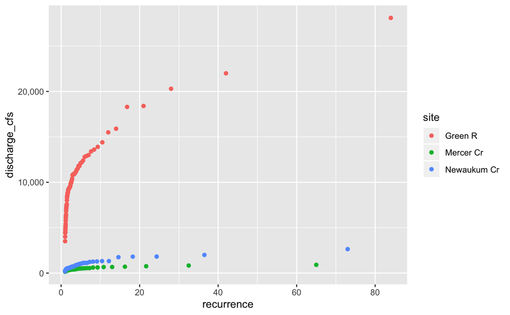

```r
floodprob.df %>%
  ggplot(aes(x = recurrence, y=discharge_cfs, color=site)) +
  geom_point() +
  scale_y_continuous(labels= comma )
```

# Log Recurrence interval plot

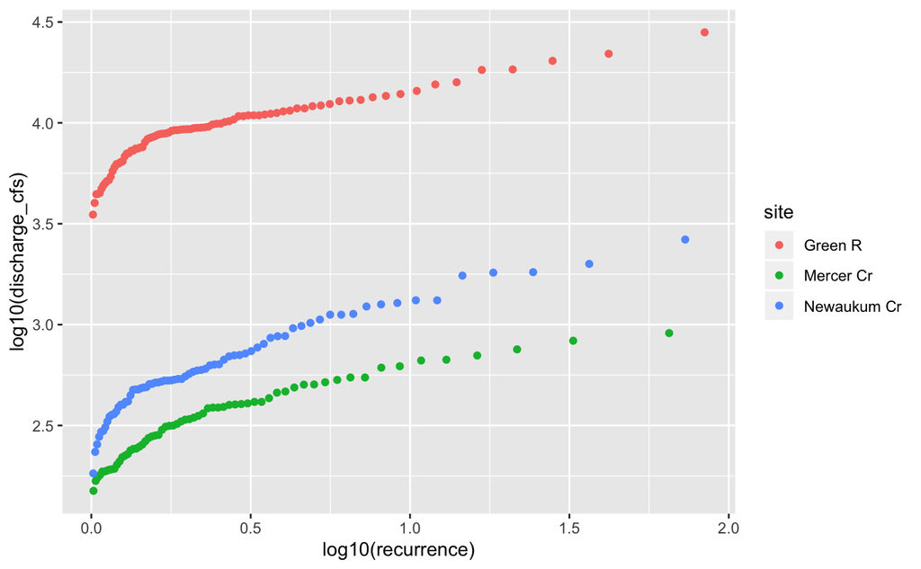

```r
floodprob.df %>%
  group_by(site) %>%
  ggplot(aes(x = log10(recurrence), y=log10(discharge_cfs), color=site)) +
  geom_point()
```

# Look at data before and after particular times

This will work withthe individual streams to look at changes before and after a particular time.

## Mercer Creek Before and after 1977

This will create a new column before and after 1977. This could be done as usual a number of different ways but this might be the easiest to work with.

```r
mercer_urban.df <- mercer.df %>%
  mutate(year = year(date)) %>%
  mutate(pre_post = case_when(
    year <= 1977 ~ "pre_1977",
    year > 1977 ~ "post_1977"
  ))
```

## Calculating probability Mercer Cr Pre Post 1977

Rather than grouping based on stream we are grouping based on pre_post 1977. This is essentially tyhe same thing we did above to caclulate probability.

```r
mercer_urban.df <- mercer_urban.df %>%
  group_by(pre_post) %>%
  arrange(desc(discharge_cfs))%>%
  mutate(rank  = 1:n()) %>%
  mutate(prob = rank / (n()+1)) %>%
  mutate(pct_prob = prob * 100) %>%
  mutate(recurrence  = 1/prob)
```

## Mercer Creek pre post recurrece interval plot

Thsi plots the data as above grouped fro Mercer Cr pre and post 1977

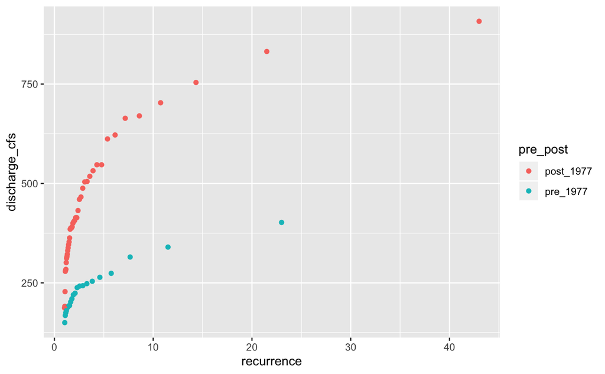

```r
mercer_urban.df %>%
  ggplot(aes(x = recurrence, y=discharge_cfs, color=pre_post)) +
  geom_point() +
  scale_y_continuous(labels = comma )
```

## Green River Dam Effects

This looks at the effect of a dam on Green River. Again this uses the same code above and since the variable names are the same we can copy the code form above to hear and change some of the values.

```r
green_dam.df <- green.df %>%
  mutate(year = year(date)) %>%
  mutate(pre_post = case_when(
    year <= 1961 ~ "pre_1961",
    year > 1961 ~ "post_1961"
  ))
```

## Calculating flood probability in Green R Pre Post 1961

```r
green_dam.df <- green_dam.df %>%
  group_by(pre_post) %>%
  arrange(desc(discharge_cfs))%>%
  mutate(rank  = 1:n()) %>%
  mutate(prob = rank / (n()+1)) %>%
  mutate(pct_prob = prob * 100) %>%
  mutate(recurrence  = 1/prob)
```

## Recurrece interval plot Green R pre post dam

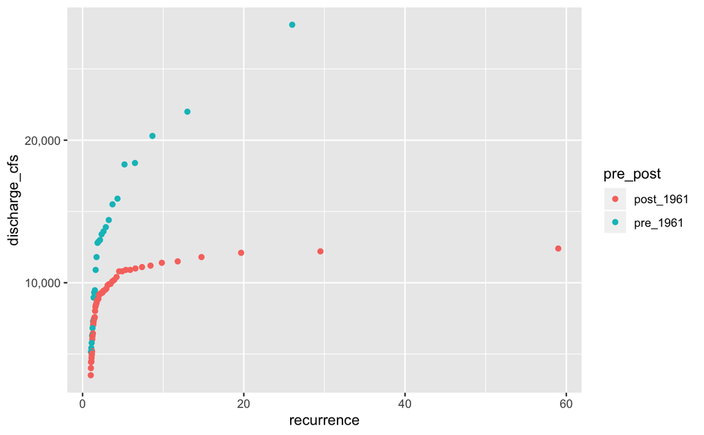

```r
green_dam.df %>%
  ggplot(aes(x = recurrence, y=discharge_cfs, color=pre_post)) +
  geom_point() +
  scale_y_continuous(labels = comma )
```

## Newaukum River Dam Effects

```r
new_dummy.df <- new.df %>%
  mutate(year = year(date)) %>%
  mutate(pre_post = case_when(
    year <= 1961 ~ "pre_1961",
    year > 1961 ~ "post_1961"
  ))
```

## Calculating flood probability Newaukum R Pre Post 1961

```r
new_dummy.df <- new_dummy.df %>%
  group_by(pre_post) %>%
  arrange(desc(discharge_cfs))%>%
  mutate(rank  = 1:n()) %>%
  mutate(prob = rank / (n()+1)) %>%
  mutate(pct_prob = prob * 100) %>%
  mutate(recurrence  = 1/prob)
```

## Newaukum R pre post recurrece interval plot

[figure not shown]